# Genetic diversity practical: heterozygosity and ROH

A statistic commonly used to represent the genetic diversity within an individual is the proportion of sites that have two different alleles, referred to as heterozygosity. While heterozygosity can refer to the proportion out of any set of markers, in this exercise we will look at the number of heterozygous sites out of all callable sites. Heterozygosity, while being a measure for the within-individual genetic variation, also provides information about the genetic variation in the population as a whole.

In this exercise we will cover:

- Filtering data to get accurate calls of heterozygous sites
- How to estimate heterozygosity for a single individual
- Why the denominator matters
- Comparing heterozygosity among individuals, populations, species, and genomic windows
- Calling and interpreting runs of homozygosity for two example individuals

Tools used: bcftools, samtools, AWK, Python/jupyterquiz, R, plink

The notebooks are editable, so feel free to experiment and change the code to see what happens, or to write notes in the text cells.

First, we define the paths for the files we need during the exercise.

```
### data paths
BAM=/davidData/users/thomas/workshop/CTauTzS_8872.Goat.bam
GOODSITES=/davidData/users/thomas/workshop/Goat.siteQC.good.bed
GOAT_REF=/davidData/users/thomas/workshop/goat.fa.gz
HET=/davidData/users/thomas/workshop/het.roh.tsv
CHR27_BCF=/davidData/users/thomas/workshop/CTauTzS_8872.chr27.filtered.bcf.gz
HET_TRAG=/davidData/users/thomas/workshop/heterozygosity_trag.txt

### make sure required software is installed
which bcftools
which samtools
which awk

### make directory for the exercise
mkdir -p "$HOME/kenya2026/GeneticDiversity"
echo "Exercise output directory: $HOME/kenya2026/GeneticDiversity"
```

```
/usr/bin/bcftools
/usr/bin/samtools
/usr/bin/awk
Exercise output directory: /home/jupyter-thomas/kenya2026/GeneticDiversity
```

Do you remember from earlier what a bam file contains? Let's try to look inside the BAM file we're going to be using as input by running the following:

```
samtools view /davidData/users/thomas/workshop/CTauTzS_8872.Goat.bam | head -n1
```

```
M_FP200000259BRL1C033R0156515682	0	NC_030808.1	219	0	77M	*	0	0	GCCTTAGGAAGCATTACTAATAAACTAGTGGAGGTGATAGAATTCCAGCTGAGCTATTTCAAATCCTAAAAGATGAT	IIIIIIIHIIIIIIIHIIIIIIIIIIIIIIHIIIHHIIFIIIIIIIIIIIIHIIFIIHHIIIIGIIEHIIHIIIHIH	NM:i:1	MD:Z:55G21	AS:i:72	XS:i:72	XA:Z:NC_030808.1,+41883292,77M,1;	XP:i:1	RG:Z:L…
samtools view: writing to standard output failed: Broken pipe
samtools view: error closing standard output: -1
```

This outputs the information for a single read coming from a single wildebeest individual, the one with ID number 8872. The BAM file contains around 242 million such reads - only from one individual! Pause a bit and think about the enormity of this data, and how much information it contains. That's the power of whole-genome sequencing.

## Filtering

Since we are using data that has not been filtered, and because heterozygosity estimation depends a lot on correctly determining which sites are truly heterozygous, we will want to employ some filters on the mapped reads. But first we will need to know the average sequencing depth of our data. This is done by first extracting the depth for every site mapped to goat chromosome 27 or "NC_030834.1" with "samtools depth" and then piping this result into AWK to compute the mean.

```
### compute depth
samtools depth /davidData/users/thomas/workshop/CTauTzS_8872.Goat.bam -r NC_030834.1 |  awk '{sum+=$3} END { print "Mean = ",sum/NR}'
```

```
Mean =  17.1806
```

Two of the filters we are going to use are given as options to bcftools below: `-Q 30 -q 25`, which tell the program to ignore bases in reads if their base calling quality score is below 30 and to ignore entire reads if their mapping quality score is below 25.

- What is the difference between base calling quality score and mapping quality score?
- What do values of 30 and 25 correspond to? (Hint: https://en.wikipedia.org/wiki/Phred_quality_score)

In addition to the quality filters, we will also set a minimum and maximum depth of sequencing for each site. Here, we exclude all sites from the estimation if they have less than half of the mean sequencing depth we just calculated, or if they have more than twice the mean depth. We add this filter because sites with unusually low or high depth are likely to be problematic. For example, high depth can arise due to paralogy, when two very similar regions in the sampled species map to a single region in the reference genome.

In addition to these basic filters, there are several others that can be considered before calling genome-wide heterozygosity. For example, repetitive sequence regions are spread across the genome of many organisms. The goat genome has about 45% repetitive sequence. Such regions can make mapping difficult and can make genotype calls unreliable. One way to identify these regions is with RepeatMasker. We will not go into the details here, but we have prepared a list of sites in advance that passed more extensive filtering. This list of "good sites" can be supplied to bcftools with the `-T` option.

It looks like this inside:

```
head /davidData/users/thomas/workshop/Goat.siteQC.good.bed
```

```
NC_030808.1	0	21
NC_030808.1	132	137
NC_030808.1	5948	5950
NC_030808.1	5951	5953
NC_030808.1	5954	5956
NC_030808.1	5957	6031
NC_030808.1	6033	6057
NC_030808.1	6058	6059
NC_030808.1	6064	6090
NC_030808.1	6091	6092
```

Run the code below to start a short quiz about filtering and callable sites.

```
from jupyterquiz import display_quiz
display_quiz('/davidData/users/thomas/workshop/heterozygosity_quiz1_filtering.json')
```

Now we are almost ready to apply these filters and call genotypes on sites that pass the filters. However, going through an entire genome and evaluating every single position takes time and processing power, and so for the purpose of demonstration we will be using data mapped to only one small region, namely positions 30,000,000 to 31,000,000 on goat chromosome 27. In a real study, we would want to base the heterozygosity estimation on as much data as possible to get the most accurate estimate.

- How large a portion of chromosome 27 is this subset of 1 million bases? What about compared to the whole genome? (Hint: Look here https://www.ncbi.nlm.nih.gov/datasets/genome/GCF_001704415.2/)

We now apply our filters and call genotypes in the small region:

```
### filtering
set -euo pipefail

bcftools mpileup --threads 10 --full-BAQ -r NC_030834.1:30000000-31000000 -T /davidData/users/thomas/workshop/Goat.siteQC.good.bed -Q 30 -q 25 -O u \
    --fasta-ref /davidData/users/thomas/workshop/goat.fa.gz --per-sample-mF -a FORMAT/AD,FORMAT/DP /davidData/users/thomas/workshop/CTauTzS_8872.Goat.bam | \
    bcftools call -Ob -o "$HOME/kenya2026/GeneticDiversity/CTauTzS_8872.subset.bcf.gz" --threads 10 -c
```

```
Note: none of --samples-file, --ploidy or --ploidy-file given, assuming all sites are diploid
[mpileup] 1 samples in 1 input files
[mpileup] maximum number of reads per input file set to -d 250
```

Next, we want to do some more processing of the output and fill out the tag "AC", which is short for "allele count". The command may look a bit scary, but if we break it down it should not be too bad. In the first part, the expression after -i removes sites where the reference or alternate allele is not a single base (non-SNPs), as well as sites where the number of reads covering it is less than half or more than double the mean depth of coverage. The next part removes any site that is called heterozygous but where only a single read supports one of the two alleles, because this is unlikely if the site is truly heterozygous, but can happen because of a single erroneous base call. The last part fills in the tag "AC" for the number of alternate alleles in the remaining sites, which is useful for inspecting the file. For the actual heterozygosity count below, we count directly from the genotype field (`GT`).

```
### more filtering and filling AC tag
set -euo pipefail

bcftools view --threads 10 -i 'strlen(REF)==1 & (strlen(ALT)==1 || ALT=".") &  FMT/DP>=8 & FMT/DP<=34' \
    -M 2 -Ou "$HOME/kenya2026/GeneticDiversity/CTauTzS_8872.subset.bcf.gz" | \
    bcftools view --threads 10 -i '(GT=="het" & FMT/AD[*:0]>=2 & FMT/AD[*:1]>=2 ) || GT=="hom"' | \
    bcftools +fill-tags /dev/stdin -Ob -o "$HOME/kenya2026/GeneticDiversity/CTauTzS_8872.subset.filtered.bcf.gz" -- -t AC
```

Let's have a look at the resulting file (-H skips the header lines that contain metadata):

```
bcftools view -H "$HOME/kenya2026/GeneticDiversity/CTauTzS_8872.subset.filtered.bcf.gz" | head -n500 | column -t
```

```
[main_vcfview] Error: cannot write to (null)
NC_030834.1  30000000  .  C  .  65.9943  .  DP=13;FS=0;MQ0F=0;AF1=0;AC1=0;DP4=4,8,0,0;MQ=60;FQ=-62.9862                                                                                                   GT:PL:DP:AD  0/0:0:12:12
NC_030834.1  30000001  .  T  .  68.9944  .  DP=13;FS=0;MQ0F=0;AF1=0;AC1=0;DP4=4,9,0,0;MQ=60;FQ=-65.9862                                                                                                   GT:PL:DP:AD  0/0:0:13:13
NC_030834.1  30000002  .  C  .  68.9944  .  DP=14;FS=0;MQ0F=0;AF1=0;AC1=0;DP4=4,9,0,0;MQ=60;FQ=-65.9862                                                                                                   GT:PL:DP:AD  0/0:0:13:13
NC_030834.1  30000003  .  T  .  65.9943  .  DP=14;FS=0;MQ0F=0;AF1=0;AC1=0;DP4=4,8,0,0;MQ=60;FQ=-62.9862                                                                                                   GT:PL:DP:AD  0/0:0:12:12
NC_030834.1  30000004  .  T  .  68.9944  .  DP=14;FS=0;MQ0F=0;AF1=0;AC1=0;DP4=4,9,0,0;MQ=60;FQ=-65.9862                                                                                                   GT:PL:DP:AD  0/0:0:13:13
NC_030834.1  30000005  .  T  .  68.9944  .  DP=13;FS=0;MQ0F=0;AF1=0;AC1=0;DP4=4,9,0,0;MQ=60;FQ=-65.9862                                                                                                   GT:PL:DP:AD  0/0:0:13:13
NC_030834.1  30000006  .  G  .  68.9944  .  DP=13;FS=0;MQ0F=0;AF1=0;AC1=0;DP4=4,9,0,0;MQ=60;FQ=-65.9862                                                                                                   GT:PL:DP:AD  0/0:0:13:13
NC_030834.1  30000007  .  A  .  65.9943  .  DP=13;FS=0;MQ0F=0;AF1=0;AC1=0;DP4=3,9,0,0;MQ=60;FQ=-62.9862                                                                                                   GT:PL:DP:AD  0/0:0:12:12
NC_030834.1  30000008  .  G  .  68.9944  .  DP=13;FS=0;MQ0F=0;AF1=0;AC1=0;DP4=4,9,0,0;MQ=60;FQ=-65.9862                                                                                                   GT:PL:DP:AD  0/0:0:13:13
NC_030834.1  30000009  .  G  .  65.9943  .  DP=13;FS=0;MQ0F=0;AF1=0;AC1=0;DP4=4,8,0,0;MQ=60;FQ=-62.9862                                                                                                   GT:PL:DP:AD  0/0:0:12:12
NC_030834.1  30000010  .  T  .  68.9944  .  DP=13;FS=0;MQ0F=0;AF1=0;AC1=0;DP4=4,9,0,0;MQ=60;FQ=-65.9862                                                                                                   GT:PL:DP:AD  0/0:0:13:13
NC_030834.1  30000011  .  A  .  62.9943  .  DP=13;FS=0;MQ0F=0;AF1=0;AC1=0;DP4=4,7,0,0;MQ=60;FQ=-59.9861                                                                                                   GT:PL:DP:AD  0/0:0:11:11
NC_030834.1  30000012  .  C  .  65.9943  .  DP=13;FS=0;MQ0F=0;AF1=0;AC1=0;DP4=4,8,0,0;MQ=60;FQ=-62.9862                                                                                                   GT:PL:DP:AD  0/0:0:12:12
NC_030834.1  30000013  .  C  .  65.9943  .  DP=13;FS=0;MQ0F=0;AF1=0;AC1=0;DP4=4,8,0,0;MQ=60;FQ=-62.9862                                                                                                   GT:PL:DP:AD  0/0:0:12:12
NC_030834.1  30000014  .  A  .  68.9944  .  DP=13;FS=0;MQ0F=0;AF1=0;AC1=0;DP4=4,9,0,0;MQ=60;FQ=-65.9862                                                                                                   GT:PL:DP:AD  0/0:0:13:13
NC_030834.1  30000015  .  G  .  68.9944  .  DP=13;FS=0;MQ0F=0;AF1=0;AC1=0;DP4=4,9,0,0;MQ=60;FQ=-65.9862                                                                                                   GT:PL:DP:AD  0/0:0:13:13
NC_030834.1  30000016  .  C  .  65.9943  .  DP=12;FS=0;MQ0F=0;AF1=0;AC1=0;DP4=4,8,0,0;MQ=60;FQ=-62.9862                                                                                                   GT:PL:DP:AD  0/0:0:12:12
NC_030834.1  30000017  .  T  .  65.9943  .  DP=12;FS=0;MQ0F=0;AF1=0;AC1=0;DP4=4,8,0,0;MQ=60;FQ=-62.9862                                                                                                   GT:PL:DP:AD  0/0:0:12:12
NC_030834.1  30000018  .  A  .  62.9943  .  DP=12;FS=0;MQ0F=0;AF1=0;AC1=0;DP4=4,7,0,0;MQ=60;FQ=-59.9861                                                                                                   GT:PL:DP:AD  0/0:0:11:11
NC_030834.1  30000019  .  T  .  68.9944  .  DP=13;FS=0;MQ0F=0;AF1=0;AC1=0;DP4=5,8,0,0;MQ=60;FQ=-65.9862                                                                                                   GT:PL:DP:AD  0/0:0:13:13
NC_030834.1  30000020  .  G  .  68.9944  .  DP=13;FS=0;MQ0F=0;AF1=0;AC1=0;DP4=5,8,0,0;MQ=60;FQ=-65.9862                                                                                                   GT:PL:DP:AD  0/0:0:13:13
NC_030834.1  30000021  .  C  .  68.9944  .  DP=14;FS=0;MQ0F=0;AF1=0;AC1=0;DP4=6,7,0,0;MQ=60;FQ=-65.9862                                                                                                   GT:PL:DP:AD  0/0:0:13:13
NC_030834.1  30000022  .  T  .  68.9944  .  DP=14;FS=0;MQ0F=0;AF1=0;AC1=0;DP4=6,7,0,0;MQ=60;FQ=-65.9862                                                                                                   GT:PL:DP:AD  0/0:0:13:13
NC_030834.1  30000023  .  T  .  65.9943  .  DP=14;FS=0;MQ0F=0;AF1=0;AC1=0;DP4=6,6,0,0;MQ=60;FQ=-62.9862                                                                                                   GT:PL:DP:AD  0/0:0:12:12
NC_030834.1  30000024  .  C  .  71.9944  .  DP=15;FS=0;MQ0F=0;AF1=0;AC1=0;DP4=7,7,0,0;MQ=60;FQ=-68.9862                                                                                                   GT:PL:DP:AD  0/0:0:14:14
```

[output cut: 476 more lines]

Note that lines above are too long to fit in the box, so they will wrap around to the next line, so only every other line is actually a new line.

- Try to see if you can find a heterozygous site in the cell above. (Hint: Start by looking at sites where the "ALT" field is not "." and then look at the genotype or "GT")
- If a site is truly heterozygous, what proportion of reads covering that site would you expect to support each of the two alleles?

## Estimation

Above, we made a cautiously filtered BCF file containing genotypes from a small region of chromosome 27. From here, the actual heterozygosity estimation is quite simple in concept: count the heterozygous sites and divide by the number of callable sites.

The important detail is the denominator. We are not dividing by the whole genome length, and we are not dividing only by variable SNPs. We are dividing by the sites that survived our filters and were therefore considered callable for this individual in this analysis.

We can count genotype classes by querying the `GT` field and using AWK to count how often each genotype occurs.

```
# Count genotype classes in the filtered subset we just made.
set -euo pipefail

bcftools query -f '[%GT]\n' "$HOME/kenya2026/GeneticDiversity/CTauTzS_8872.subset.filtered.bcf.gz" | \
awk '
  $1 ~ /^0[\/|]0$/ {hom_ref++}
  $1 ~ /^0[\/|]1$|^1[\/|]0$/ {het++}
  $1 ~ /^1[\/|]1$/ {hom_alt++}
  END {
    total = hom_ref + het + hom_alt
    if (total == 0) {
      print "ERROR: no callable genotypes were counted. Check that CTauTzS_8872.subset.filtered.bcf.gz exists and contains GT calls." > "/dev/stderr"
      exit 1
    }
    print ".", hom_ref + 0
    print "1", het + 0
    print "2", hom_alt + 0
  }
' > "$HOME/kenya2026/GeneticDiversity/CTauTzS_8872.subset.AC"
```

```
cat "$HOME/kenya2026/GeneticDiversity/CTauTzS_8872.subset.AC"
```

```
. 451568
1 907
2 15607
```

Saved to the file above we have the counts of sites that are homozygous for the reference allele, sites that are heterozygous, and sites that are homozygous for the alternative allele.

- `.` means homozygous reference genotype (`0/0`).
- `1` means heterozygous genotype (`0/1` or `1/0`).
- `2` means homozygous alternate genotype (`1/1`).

What do you think could be the reason for the large number of sites homozygous for the alternative allele? Hint: what is the reference genome, and what species is this individual?

Run the code below to start a short quiz about the denominator in heterozygosity estimates.

```
from jupyterquiz import display_quiz
display_quiz('/davidData/users/thomas/workshop/heterozygosity_quiz2_denominator.json')
```

```
# Heterozygosity = heterozygous sites / all callable sites.
awk '
  $1=="." {hom_ref=$2}
  $1=="1" {het=$2}
  $1=="2" {hom_alt=$2}
  END {
    total = hom_ref + het + hom_alt
    print "hom_ref_sites =", hom_ref
    print "het_sites     =", het
    print "hom_alt_sites =", hom_alt
    print "callable_sites=", total
    print "heterozygosity=", het / total
  }
' "$HOME/kenya2026/GeneticDiversity/CTauTzS_8872.subset.AC"
```

```
hom_ref_sites = 451568
het_sites     = 907
hom_alt_sites = 15607
callable_sites= 468082
heterozygosity= 0.00193769
```

### What if we only used variable sites?

A common trap is to estimate heterozygosity only from sites already known to be variable. That changes the denominator. Below we compare the heterozygosity estimate using all callable sites with a SNP-only style estimate that ignores homozygous reference sites.

```
awk '
  $1=="." {hom_ref=$2}
  $1=="1" {het=$2}
  $1=="2" {hom_alt=$2}
  END {
    callable_total = hom_ref + het + hom_alt
    alt_site_total = het + hom_alt
    print "all callable sites:       ", het / callable_total
    print "ALT/SNP sites only:       ", het / alt_site_total
    print "fold difference:          ", (het / alt_site_total) / (het / callable_total)
  }
' "$HOME/kenya2026/GeneticDiversity/CTauTzS_8872.subset.AC"
```

```
all callable sites:        0.00193769
ALT/SNP sites only:        0.0549231
fold difference:           28.3446
```

- Why is the SNP-only value so different?
- Which estimate of the two do you think is closer to the "true" heterozygosity?
- When might a SNP-only estimate still be useful?

```
# Now count genotype classes for the precomputed whole chromosome 27 file.
set -euo pipefail

bcftools query -f '[%GT]\n' /davidData/users/thomas/workshop/CTauTzS_8872.chr27.filtered.bcf.gz | \
awk '
  $1 ~ /^0[\/|]0$/ {hom_ref++}
  $1 ~ /^0[\/|]1$|^1[\/|]0$/ {het++}
  $1 ~ /^1[\/|]1$/ {hom_alt++}
  END {
    total = hom_ref + het + hom_alt
    if (total == 0) {
      print "ERROR: no callable genotypes were counted. Check that CHR27_BCF exists and contains GT calls." > "/dev/stderr"
      exit 1
    }
    print ".", hom_ref + 0
    print "1", het + 0
    print "2", hom_alt + 0
  }
' > "$HOME/kenya2026/GeneticDiversity/CTauTzS_8872.chr27.AC"

cat "$HOME/kenya2026/GeneticDiversity/CTauTzS_8872.chr27.AC"

awk '
  $1=="." {hom_ref=$2}
  $1=="1" {het=$2}
  $1=="2" {hom_alt=$2}
  END {
    total = hom_ref + het + hom_alt
    print "chromosome_27_heterozygosity =", het / total
  }
' "$HOME/kenya2026/GeneticDiversity/CTauTzS_8872.chr27.AC"
```

```
. 19812664
1 36584
2 737872
chromosome_27_heterozygosity = 0.00177703
```

Now compare the subset estimate to a precomputed file covering all of chromosome 27. This is the same filtering idea as above, but applied to much more sequence.

- Why do you get different values on the whole chromosome compared to the small region/subset?
- Which estimate should we usually trust more, and why?
- Then try to run the filtering and estimation again with one or more filters changed or removed. For example, look at `-T`, `-Q`, `-q`, or the depth cutoffs. What changes?

## Heterozygosity Along a Chromosome

A single chromosome-wide value can still hide local variation. Here we estimate heterozygosity in 1 Mb windows along chromosome 27 using the precomputed filtered BCF file. This is still heterozygosity, just summarized locally instead of across the whole chromosome.

```
set -euo pipefail

bcftools query -f '%POS[\t%GT]\n' /davidData/users/thomas/workshop/CTauTzS_8872.chr27.filtered.bcf.gz | \
awk -v w=1000000 '
  BEGIN {OFS="\t"; print "window_start", "window_end", "callable_sites", "het_sites", "heterozygosity"}
  {
    bin = int(($1 - 1) / w) + 1
    total[bin]++
    if ($2 ~ /^0[\/|]1$|^1[\/|]0$/) het[bin]++
  }
  END {
    for (b = 1; b <= 60; b++) {
      if (total[b] > 0) print (b - 1) * w + 1, b * w, total[b], het[b] + 0, (het[b] + 0) / total[b]
    }
  }
' > "$HOME/kenya2026/GeneticDiversity/CTauTzS_8872.chr27.window_het.tsv"

head -n 20 "$HOME/kenya2026/GeneticDiversity/CTauTzS_8872.chr27.window_het.tsv" | column -t
```

```
window_start  window_end  callable_sites  het_sites  heterozygosity
1             1000000     366310          848        0.00231498
1000001       2000000     411292          927        0.00225387
2000001       3000000     395170          1113       0.00281651
3000001       4000000     402876          678        0.0016829
4000001       5000000     464385          853        0.00183684
5000001       6000000     450195          909        0.00201913
6000001       7000000     501941          1203       0.0023967
7000001       8000000     448035          558        0.00124544
8000001       9000000     465672          7          1.5032e-05
9000001       10000000    475343          948        0.00199435
10000001      11000000    376758          965        0.00256133
11000001      12000000    420455          991        0.00235697
12000001      13000000    480060          733        0.00152689
13000001      14000000    529700          1093       0.00206343
14000001      15000000    513747          241        0.000469102
15000001      16000000    474665          745        0.00156953
16000001      17000000    472545          954        0.00201886
17000001      18000000    538116          137        0.000254592
18000001      19000000    516308          1013       0.00196201
```

```
options(repr.plot.width = 12, repr.plot.height = 5)
window_het <- read.table(path.expand("~/kenya2026/GeneticDiversity/CTauTzS_8872.chr27.window_het.tsv"), header = TRUE)

# Simple binomial SE for the proportion of heterozygous sites.
# This ignores linkage, genotype uncertainty, and mapping/callability effects.
window_het$se <- with(window_het,
    sqrt(heterozygosity * (1 - heterozygosity) / callable_sites))

with(window_het, {
    x <- window_start / 1e6
    plot(x, heterozygosity, type="b", pch=19, col="#006f68",
         xlab="Chromosome 27 position (Mb)", ylab="Heterozygosity")
    arrows(x, heterozygosity-se, x, heterozygosity+se,
           angle=90, code=3, length=0.03, col="#006f68")
})

abline(h=mean(window_het$heterozygosity), col="#d96c4f", lty=2)
```

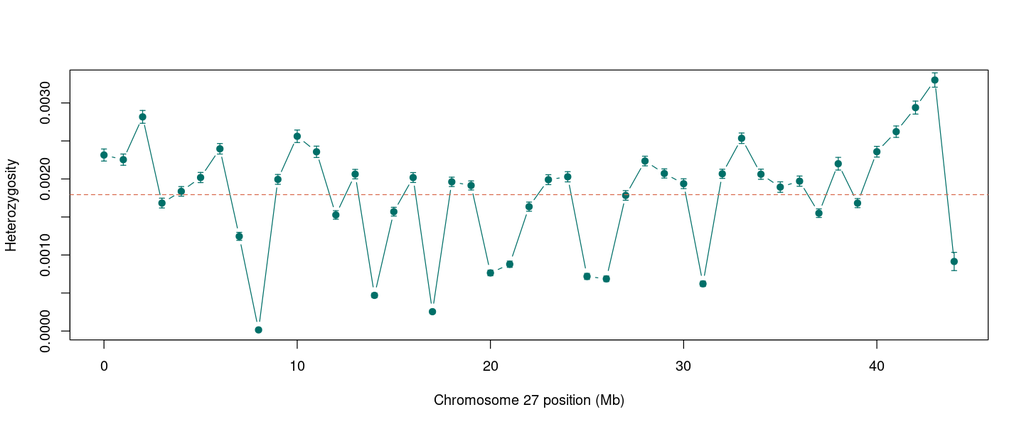

- Are heterozygous sites evenly distributed along the chromosome?
- What could cause windows with unusually low heterozygosity?
- Which possibilities are biological, and which are technical?

This windowed view is a natural bridge to ROH: long stretches with very low heterozygosity may reflect recent shared ancestry, but low callability, mapping problems, or other filters can also produce local dips.

## Comparison between individuals

In isolation the heterozygosity value we just estimated does not tell us much, so we will need something to compare it to. In general, compared to other large African mammals, this value is on the low side, but let's look at some more wildebeest samples in comparison. While we could have estimated values for more individuals by repeating the previous procedure, we have cheated a bit and done this ahead of time, saving the heterozygosities estimated on whole genomes in a file where the relevant values look like this:

```
cut /davidData/users/thomas/workshop/het.roh.tsv -f1,6,7 | column -t
```

```
sampleID      het       map
CTauNaN_2489  0.00267   B-Etosha
CTauNaN_2495  0.002747  B-Etosha
CTauNaN_2496  0.002757  B-Etosha
CTauNaN_2500  0.00274   B-Etosha
CTauNaN_2503  0.002765  B-Etosha
CTauNaN_2506  0.00275   B-Etosha
CTauZmC_3748  0.002391  B-Kafue
CTauZmC_3745  0.002426  B-Kafue
CTauZmC_3746  0.002316  B-Kafue
CTauZmC_3747  0.002363  B-Kafue
CTauZmE_2542  0.001938  C-Luangwa
CTauZmE_2552  0.001909  C-Luangwa
CTauZmE_3749  0.001803  C-Luangwa
CTauTzN_2165  0.002087  E-Monduli
CTauTzN_2199  0.00214   E-Monduli
CTauTzN_3171  0.002388  E-Monduli
CTauTzN_3172  0.002082  E-Monduli
CTauTzN_4275  0.002155  E-Monduli
CTauTzN_4276  0.002153  E-Monduli
CTauTzN_4279  0.00213   E-Monduli
CTauTzN_4498  0.00212   E-Monduli
CTauTzN_4499  0.002121  E-Monduli
CTauTzN_4501  0.002147  E-Monduli
CTauTzN_4502  0.002111  E-Monduli
CTauKeS__698  0.002069  E.wBearded_KeSAmb
CTauKeS__699  0.00212   E.wBearded_KeSAmb
CTauKeS__700  0.002064  E.wBearded_KeSAmb
CTauKeS__701  0.002099  E.wBearded_KeSAmb
CTauKeS__702  0.002052  E.wBearded_KeSAmb
CTauKeS__704  0.002087  E.wBearded_KeSAmb
CTauKeS__705  0.00208   E.wBearded_KeSAmb
CTauKeS__706  0.002078  E.wBearded_KeSAmb
CTauKeS__707  0.002119  E.wBearded_KeSAmb
CTauKeS__709  0.001905  E.wBearded_KeSNai
CTauKeS__710  0.001866  E.wBearded_KeSNai
CTauKeS__711  0.001947  E.wBearded_KeSNai
CTauKeS__712  0.001912  E.wBearded_KeSNai
CTauKeS__713  0.001916  E.wBearded_KeSNai
CTauKeS__714  0.001931  E.wBearded_KeSNai
```

[output cut: 17 more lines]

```
CTauTzN_4497  0.002381  W.wBearded
CTauTzN_5188  0.002408  W.wBearded
CTauTzN_8202  0.002282  W.wBearded
CTauTzN_8870  0.002377  W.wBearded
CTauTzN_8871  0.002369  W.wBearded
CTauTzN_3174  0.002379  W.wBearded
CTauTzN__738  0.002454  W.wBearded
CTauTzN__740  0.002356  W.wBearded
CTauTzN__741  0.002393  W.wBearded
CTauTzN__742  0.002371  W.wBearded
CTauTzN__744  0.002349  W.wBearded
CTauTzN__746  0.002371  W.wBearded
CTauTzN__747  0.002288  W.wBearded
CTauTzN__750  0.00227   W.wBearded
CTauTzN__751  0.002296  W.wBearded
```

To get a better overview of these values, we can plot them in, for example, a boxplot separated by a grouping of interest such as population, locality, or species. Here the field "map" denotes locality, and we can use this information to separate the samples into groups.

```
options(repr.plot.width = 16, repr.plot.height = 10)
het_table <- read.table("/davidData/users/thomas/workshop/het.roh.tsv", header = TRUE)
boxplot(het ~ map, data = het_table, col = "#4fb3a4", ylab = "Heterozygosity")
```

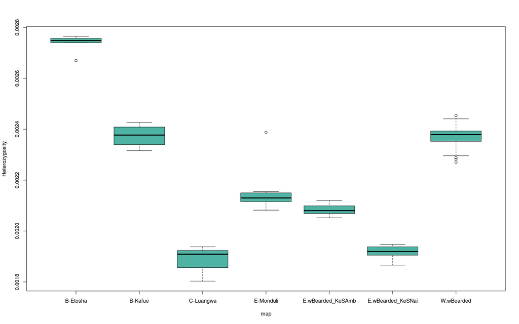

Now we have a better overview of the distributions of heterozygosity.

Finally, we have also estimated heterozygosity in a similar manner from a range of other species belonging to the Tragelaphines, or spiral-horned antelopes. Here we plot these values to allow comparison with the wildebeests.

```
het_table_trag <- read.table("/davidData/users/thomas/workshop/heterozygosity_trag.txt", header = FALSE)
names <- c("Tory" = "eland", "Tder" = "giant_eland", "Tstr" = "greater_kudu", "Timb" = "lesser_kudu", "Tbux" = "mountain_nyala", "Scaf" = "nyala", "Tspe" = "sitatunga", "Tscr" = "bushbuck")

het_table_trag$species <- names[substr(het_table_trag$V1, 1, 4)]
het_table_wildebeest <- data.frame(V1 = het_table$sampleID, V2 = het_table$het, species = rep("wildebeest", dim(het_table)[1]))
het_table_species <- rbind(het_table_trag, het_table_wildebeest)

boxplot(V2 ~ species, data = het_table_species, col = "#d96c4f", ylab = "Heterozygosity")
```

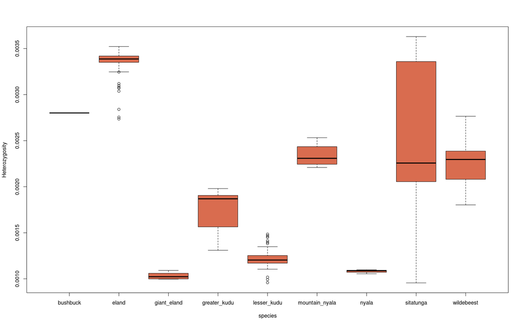

- What extra technical caveats matter when comparing heterozygosity across species mapped to the same goat reference genome?

# Part 2: Runs of Homozygosity

Genome-wide heterozygosity gives one summary value per individual, but it does not tell us how homozygosity is arranged along the genome. Runs of homozygosity, or ROH, are long stretches where an individual is homozygous at many consecutive SNPs. Long ROH are usually interpreted as segments inherited identical-by-descent from a recent shared ancestor.

Here we compare two wildebeest individuals with contrasting ROH patterns:

- `CTauBwC__761`
- `CTauZmE_2542`

The PLINK file we use here is close to the starting point used in the original article, but it is not quite the final ROH input. The original project also masked heterozygous genotypes with suspicious allele balance before PLINK conversion, but we skip that step here for technical reasons. We still use the rest of the filtering as in the article: population-specific MAF and missingness filters, followed by removal of sites with unusually high observed heterozygosity.

```
### Work inside the course directory.
mkdir -p "$HOME/kenya2026/GeneticDiversity/ROH"
echo "ROH output directory: $HOME/kenya2026/GeneticDiversity/ROH"

### Check that the files and tools exist.
ls -lh /davidData/users/thomas/workshop/Wildebeest_wildebeest_variable_sites_nomultiallelics_noindels_10dp_3het.MAF005.bed \
       /davidData/users/thomas/workshop/Wildebeest_wildebeest_variable_sites_nomultiallelics_noindels_10dp_3het.MAF005.bim \
       /davidData/users/thomas/workshop/Wildebeest_wildebeest_variable_sites_nomultiallelics_noindels_10dp_3het.MAF005.fam
/emily/program/bin/plink --version
```

```
ROH output directory: /home/jupyter-thomas/kenya2026/GeneticDiversity/ROH
-rw-r--r-- 1 thomas users 488M Aug 11 12:42 /davidData/users/thomas/workshop/Wildebeest_wildebeest_variable_sites_nomultiallelics_noindels_10dp_3het.MAF005.bed
-rw-r--r-- 1 thomas users 873M Aug 11 12:42 /davidData/users/thomas/workshop/Wildebeest_wildebeest_variable_sites_nomultiallelics_noindels_10dp_3het.MAF005.bim
-rw-r--r-- 1 thomas users 3.1K Aug 11 12:42 /davidData/users/thomas/workshop/Wildebeest_wildebeest_variable_sites_nomultiallelics_noindels_10dp_3het.MAF005.fam
PLINK v1.90b6 64-bit (26 May 2018)
```

We define population lists that should be confirmed with analysis of population structure. For this exercise we derive two small groups from sample-name prefixes so the filtering is transparent and self-contained. In a real analysis, we would use the curated population assignment file from the project.

The `--allow-extra-chr` option is needed because the wildebeest assembly uses scaffold names such as `HiC_scaffold_1` rather than chromosome codes like `1`, `2`, `3`.

```
### Population-like groups for the two target individuals.
ROHDIR="$HOME/kenya2026/GeneticDiversity/ROH"
mkdir -p "$ROHDIR"

awk '$2 ~ /^CTauBwC/ {print $1, $2}' /davidData/users/thomas/workshop/Wildebeest_wildebeest_variable_sites_nomultiallelics_noindels_10dp_3het.MAF005.fam > "$ROHDIR/CTauBwC.list"
awk '$2 ~ /^CTauZmE/ {print $1, $2}' /davidData/users/thomas/workshop/Wildebeest_wildebeest_variable_sites_nomultiallelics_noindels_10dp_3het.MAF005.fam > "$ROHDIR/CTauZmE.list"

wc -l "$ROHDIR/CTauBwC.list" "$ROHDIR/CTauZmE.list"
head "$ROHDIR/CTauBwC.list" "$ROHDIR/CTauZmE.list"
```

```
  9 /home/jupyter-thomas/kenya2026/GeneticDiversity/ROH/CTauBwC.list
  3 /home/jupyter-thomas/kenya2026/GeneticDiversity/ROH/CTauZmE.list
 12 total
==> /home/jupyter-thomas/kenya2026/GeneticDiversity/ROH/CTauBwC.list <==
0 CTauBwC__760
0 CTauBwC__761
0 CTauBwC__762
0 CTauBwC__763
0 CTauBwC__764
0 CTauBwC__765
0 CTauBwC__766
0 CTauBwC__767
0 CTauBwC__769

==> /home/jupyter-thomas/kenya2026/GeneticDiversity/ROH/CTauZmE.list <==
0 CTauZmE_2542
0 CTauZmE_2552
0 CTauZmE_3749
```

First apply filters at the group level:

- `--maf 0.05`: keep variants that are polymorphic enough within the group
- `--geno 0.05`: remove variants with too much missing data
- `--hardy`: calculate observed heterozygosity per SNP

Then remove sites where the observed heterozygosity is 0.5 or above. These high-heterozygosity sites are suspicious for ROH calling because they can reflect mapping/paralogy problems and can break true homozygous tracts into smaller pieces.

This is a useful contrast with the heterozygosity part of the exercise. For genome-wide heterozygosity we cared a lot about defining callable bases. For ROH we need a marker set that does not contain many false heterozygous genotypes.

```
set -euo pipefail
cd "$HOME/kenya2026/GeneticDiversity/ROH"

for pop in CTauBwC CTauZmE; do
  echo "### Filtering $pop"

  /emily/program/bin/plink \
    --bfile /davidData/users/thomas/workshop/Wildebeest_wildebeest_variable_sites_nomultiallelics_noindels_10dp_3het.MAF005 \
    --keep ${pop}.list \
    --allow-extra-chr \
    --maf 0.05 \
    --geno 0.05 \
    --hardy \
    --make-bed \
    --out ${pop}_maf05_geno005

  awk 'NR > 1 && $7 >= 0.5 {print $2}' ${pop}_maf05_geno005.hwe > ${pop}_OHE05.sites

  ### This text report is large and not needed after extracting the high-het site list.
  rm -f ${pop}_maf05_geno005.hwe

  echo -n "Variants after MAF/missingness filtering: "
  wc -l ${pop}_maf05_geno005.bim
  echo -n "High-observed-heterozygosity sites to exclude: "
  wc -l ${pop}_OHE05.sites
  echo
 done
```

```
### Filtering CTauBwC
PLINK v1.90b6 64-bit (26 May 2018)             www.cog-genomics.org/plink/1.9/
(C) 2005-2018 Shaun Purcell, Christopher Chang   GNU General Public License v3
Logging to CTauBwC_maf05_geno005.log.
Options in effect:
  --allow-extra-chr
  --bfile /davidData/users/thomas/workshop/Wildebeest_wildebeest_variable_sites_nomultiallelics_noindels_10dp_3het.MAF005
  --geno 0.05
  --hardy
  --keep CTauBwC.list
  --maf 0.05
  --make-bed
  --out CTauBwC_maf05_geno005

386830 MB RAM detected; reserving 193415 MB for main workspace.
15493204 variants loaded from .bim file.
131 people (0 males, 0 females, 131 ambiguous) loaded from .fam.
Ambiguous sex IDs written to CTauBwC_maf05_geno005.nosex .
--keep: 9 people remaining.
Using 1 thread (no multithreaded calculations invoked).
Before main variant filters, 9 founders and 0 nonfounders present.
Calculating allele frequencies... 10111213141516171819202122232425262728293031323334353637383940414243444546474849505152535455565758596061626364656667686970717273747576777879808182838485868788899091929394959697989 done.
Total genotyping rate in remaining samples is 0.866418.
9212750 variants removed due to missing genotype data (--geno).
--hardy: Writing Hardy-Weinberg report (founders only) to
CTauBwC_maf05_geno005.hwe ... 101112131415161718192021222324252627282930313233343536373839404142434445464748495051525354555657585960616263646566676869707172737475767778798081828384858687888990919293949596979899done.
2526609 variants removed due to minor allele threshold(s)
(--maf/--max-maf/--mac/--max-mac).
3753845 variants and 9 people pass filters and QC.
Note: No phenotypes present.
--make-bed to CTauBwC_maf05_geno005.bed + CTauBwC_maf05_geno005.bim +
CTauBwC_maf05_geno005.fam ... 101112131415161718192021222324252627282930313233343536373839404142434445464748495051525354555657585960616263646566676869707172737475767778798081828384858687888990919293949596979899done.
Variants after MAF/missingness filtering: 3753845 CTauBwC_maf05_geno005.bim
High-observed-heterozygosity sites to exclude: 658814 CTauBwC_OHE05.sites

### Filtering CTauZmE
PLINK v1.90b6 64-bit (26 May 2018)             www.cog-genomics.org/plink/1.9/
(C) 2005-2018 Shaun Purcell, Christopher Chang   GNU General Public License v3
Logging to CTauZmE_maf05_geno005.log.
Options in effect:
```

[output cut: 14 more lines]

```
Using 1 thread (no multithreaded calculations invoked).
Before main variant filters, 3 founders and 0 nonfounders present.
Calculating allele frequencies... 10111213141516171819202122232425262728293031323334353637383940414243444546474849505152535455565758596061626364656667686970717273747576777879808182838485868788899091929394959697989 done.
Total genotyping rate in remaining samples is 0.949414.
2152871 variants removed due to missing genotype data (--geno).
--hardy: Writing Hardy-Weinberg report (founders only) to
CTauZmE_maf05_geno005.hwe ... 101112131415161718192021222324252627282930313233343536373839404142434445464748495051525354555657585960616263646566676869707172737475767778798081828384858687888990919293949596979899done.
9477201 variants removed due to minor allele threshold(s)
(--maf/--max-maf/--mac/--max-mac).
3863132 variants and 3 people pass filters and QC.
Note: No phenotypes present.
--make-bed to CTauZmE_maf05_geno005.bed + CTauZmE_maf05_geno005.bim +
CTauZmE_maf05_geno005.fam ... 101112131415161718192021222324252627282930313233343536373839404142434445464748495051525354555657585960616263646566676869707172737475767778798081828384858687888990919293949596979899done.
Variants after MAF/missingness filtering: 3863132 CTauZmE_maf05_geno005.bim
High-observed-heterozygosity sites to exclude: 1409321 CTauZmE_OHE05.sites
```

Before moving on:

- Why do we remove SNPs with very high observed heterozygosity before calling ROH?
- Why are the MAF and missingness filters applied within the two population-like groups rather than across all wildebeest samples at once?

Now we infer ROH for the two focal individuals with the following parameters:

- `--homozyg-kb 1000`: only report ROH at least 1 Mb long
- `--homozyg-window-het 3`: allow a few heterozygous calls inside the sliding window
- `--homozyg-window-missing 20`: allow some missing calls inside the sliding window

Allowing a few heterozygous or missing calls is practical because genotype errors and missing data can otherwise break true ROH into smaller pieces.

```
set -euo pipefail
cd "$HOME/kenya2026/GeneticDiversity/ROH"

for sample in CTauBwC__761 CTauZmE_2542; do
  if [ "$sample" = "CTauBwC__761" ]; then
    pop=CTauBwC
  else
    pop=CTauZmE
  fi

  printf '0 %s\n' "$sample" > ${sample}.keep

  /emily/program/bin/plink \
    --bfile ${pop}_maf05_geno005 \
    --keep ${sample}.keep \
    --exclude ${pop}_OHE05.sites \
    --allow-extra-chr \
    --homozyg \
    --homozyg-kb 1000 \
    --homozyg-window-het 3 \
    --homozyg-window-missing 20 \
    --out ${sample}_OHE05

  ### PLINK can write a very large per-SNP summary file. We do not need it here.
  rm -f ${sample}_OHE05.hom.summary
 done
```

```
PLINK v1.90b6 64-bit (26 May 2018)             www.cog-genomics.org/plink/1.9/
(C) 2005-2018 Shaun Purcell, Christopher Chang   GNU General Public License v3
Logging to CTauBwC__761_OHE05.log.
Options in effect:
  --allow-extra-chr
  --bfile CTauBwC_maf05_geno005
  --exclude CTauBwC_OHE05.sites
  --homozyg
  --homozyg-kb 1000
  --homozyg-window-het 3
  --homozyg-window-missing 20
  --keep CTauBwC__761.keep
  --out CTauBwC__761_OHE05

386830 MB RAM detected; reserving 193415 MB for main workspace.
3753845 variants loaded from .bim file.
9 people (0 males, 0 females, 9 ambiguous) loaded from .fam.
Ambiguous sex IDs written to CTauBwC__761_OHE05.nosex .
--exclude: 3095031 variants remaining.
--keep: 1 person remaining.
Using 1 thread (no multithreaded calculations invoked).
Before main variant filters, 1 founder and 0 nonfounders present.
Calculating allele frequencies... 10111213141516171819202122232425262728293031323334353637383940414243444546474849505152535455565758596061626364656667686970717273747576777879808182838485868788899091929394959697989 done.
3095031 variants and 1 person pass filters and QC.
Note: No phenotypes present.
--homozyg: Scan complete, found 5 ROH.
Results saved to CTauBwC__761_OHE05.hom + CTauBwC__761_OHE05.hom.indiv +
CTauBwC__761_OHE05.hom.summary .
PLINK v1.90b6 64-bit (26 May 2018)             www.cog-genomics.org/plink/1.9/
(C) 2005-2018 Shaun Purcell, Christopher Chang   GNU General Public License v3
Logging to CTauZmE_2542_OHE05.log.
Options in effect:
  --allow-extra-chr
  --bfile CTauZmE_maf05_geno005
  --exclude CTauZmE_OHE05.sites
  --homozyg
  --homozyg-kb 1000
  --homozyg-window-het 3
  --homozyg-window-missing 20
  --keep CTauZmE_2542.keep
  --out CTauZmE_2542_OHE05

386830 MB RAM detected; reserving 193415 MB for main workspace.
3863132 variants loaded from .bim file.
3 people (0 males, 0 females, 3 ambiguous) loaded from .fam.
Ambiguous sex IDs written to CTauZmE_2542_OHE05.nosex .
--exclude: 2453811 variants remaining.
--keep: 1 person remaining.
Using 1 thread (no multithreaded calculations invoked).
Before main variant filters, 1 founder and 0 nonfounders present.
Calculating allele frequencies... 10111213141516171819202122232425262728293031323334353637383940414243444546474849505152535455565758596061626364656667686970717273747576777879808182838485868788899091929394959697989 done.
2453811 variants and 1 person pass filters and QC.
Note: No phenotypes present.
--homozyg: Scan complete, found 137 ROH.
Results saved to CTauZmE_2542_OHE05.hom + CTauZmE_2542_OHE05.hom.indiv +
CTauZmE_2542_OHE05.hom.summary .
```

Before looking at the plots:

- What would a false heterozygous genotype do to a true homozygous tract?
- Why do we allow a few heterozygous or missing calls inside the ROH window instead of requiring perfect homozygosity at every SNP?

The individual summary gives the number of ROH segments (`NSEG`), total length in ROH (`KB`), and average ROH length (`KBAVG`).

```
cd "$HOME/kenya2026/GeneticDiversity/ROH"

for sample in CTauBwC__761 CTauZmE_2542; do
  echo "### $sample"
  column -t ${sample}_OHE05.hom.indiv
  echo
 done
```

```
### CTauBwC__761
FID  IID           PHE  NSEG  KB       KBAVG
0    CTauBwC__761  -9   5     7611.34  1522.27

### CTauZmE_2542
FID  IID           PHE  NSEG  KB      KBAVG
0    CTauZmE_2542  -9   137   269124  1964.41
```

Removing suspicious heterozygous sites can increase the number or length of inferred ROH, because false heterozygous genotypes can break long homozygous tracts.

Look at the longest segments for each individual.

```
cd "$HOME/kenya2026/GeneticDiversity/ROH"

for sample in CTauBwC__761 CTauZmE_2542; do
  echo "### Longest ROH for $sample"
  sort -k9,9nr ${sample}_OHE05.hom | head -10 | column -t
  echo
 done
```

```
### Longest ROH for CTauBwC__761
0    CTauBwC__761  -9.000  HiC_scaffold_27  HiC_scaffold_27:16779558:C:G  HiC_scaffold_27:18461809:C:T  16779558  18461809  1682.252  1957  0.860    0.997  0.003
0    CTauBwC__761  -9.000  HiC_scaffold_20  HiC_scaffold_20:9983413:C:G   HiC_scaffold_20:11574897:C:T  9983413   11574897  1591.485  2704  0.589    0.996  0.004
0    CTauBwC__761  -9.000  HiC_scaffold_12  HiC_scaffold_12:63675246:C:T  HiC_scaffold_12:65220322:A:G  63675246  65220322  1545.077  1040  1.486    0.997  0.003
0    CTauBwC__761  -9.000  HiC_scaffold_7   HiC_scaffold_7:36875403:G:T   HiC_scaffold_7:38391912:C:T   36875403  38391912  1516.510  1875  0.809    0.996  0.004
0    CTauBwC__761  -9.000  HiC_scaffold_20  HiC_scaffold_20:21409835:C:T  HiC_scaffold_20:22685854:C:T  21409835  22685854  1276.020  1063  1.200    0.995  0.005
FID  IID           PHE     CHR              SNP1                          SNP2                          POS1      POS2      KB        NSNP  DENSITY  PHOM   PHET

### Longest ROH for CTauZmE_2542
0  CTauZmE_2542  -9.000  HiC_scaffold_21  HiC_scaffold_21:34991921:C:T  HiC_scaffold_21:41660793:A:G  34991921  41660793  6668.873  8405  0.793  0.998  0.002
0  CTauZmE_2542  -9.000  HiC_scaffold_18  HiC_scaffold_18:45111314:C:T  HiC_scaffold_18:51208880:C:T  45111314  51208880  6097.567  8534  0.715  0.999  0.001
0  CTauZmE_2542  -9.000  HiC_scaffold_13  HiC_scaffold_13:73997821:A:G  HiC_scaffold_13:79518133:C:G  73997821  79518133  5520.313  7907  0.698  0.998  0.002
0  CTauZmE_2542  -9.000  HiC_scaffold_14  HiC_scaffold_14:77824438:A:G  HiC_scaffold_14:83140665:C:T  77824438  83140665  5316.228  7589  0.701  0.999  0.001
0  CTauZmE_2542  -9.000  HiC_scaffold_4   HiC_scaffold_4:63526207:C:T   HiC_scaffold_4:68666268:A:C   63526207  68666268  5140.062  5457  0.942  0.999  0.001
0  CTauZmE_2542  -9.000  HiC_scaffold_1   HiC_scaffold_1:45717163:A:G   HiC_scaffold_1:49791559:C:T   45717163  49791559  4074.397  4950  0.823  0.997  0.003
0  CTauZmE_2542  -9.000  HiC_scaffold_15  HiC_scaffold_15:48423184:A:G  HiC_scaffold_15:52431592:C:G  48423184  52431592  4008.409  4660  0.860  0.997  0.003
0  CTauZmE_2542  -9.000  HiC_scaffold_27  HiC_scaffold_27:15423423:C:G  HiC_scaffold_27:19372438:A:G  15423423  19372438  3949.016  4480  0.881  0.998  0.002
0  CTauZmE_2542  -9.000  HiC_scaffold_9   HiC_scaffold_9:54011319:C:T   HiC_scaffold_9:57930789:A:T   54011319  57930789  3919.471  6565  0.597  0.999  0.001
0  CTauZmE_2542  -9.000  HiC_scaffold_20  HiC_scaffold_20:28105092:G:T  HiC_scaffold_20:31886211:A:T  28105092  31886211  3781.120  5118  0.739  0.998  0.002
```

For plotting, we make group-level filtered PLINK files and then thin them to every 20th SNP. The ROH calls above are based on the denser filtered marker set; thinning is only for making the example plotting command fast enough to run.

The plot shows:

- blue: retained SNP/scaffold track
- red: heterozygous SNPs
- purple: SNP density
- grey: heterozygosity in windows
- black/grey horizontal segments: PLINK ROH

The schematic below labels these tracks in the output of the plotting script:

[figure not shown]

Because the input is a variable-site SNP dataset, the red marks are heterozygous SNPs among retained SNPs. This is not the same visual scale as heterozygous bases divided by all callable bases.

```
set -euo pipefail
cd "$HOME/kenya2026/GeneticDiversity/ROH"

for pop in CTauBwC CTauZmE; do
  /emily/program/bin/plink \
    --bfile ${pop}_maf05_geno005 \
    --exclude ${pop}_OHE05.sites \
    --allow-extra-chr \
    --make-bed \
    --out ${pop}_OHE05_group

  awk 'NR % 20 == 0 {print $2}' ${pop}_OHE05_group.bim > ${pop}_OHE05_group_plot.extract

  /emily/program/bin/plink \
    --bfile ${pop}_OHE05_group \
    --allow-extra-chr \
    --extract ${pop}_OHE05_group_plot.extract \
    --make-bed \
    --out ${pop}_OHE05_group_plot
 done
```

```
PLINK v1.90b6 64-bit (26 May 2018)             www.cog-genomics.org/plink/1.9/
(C) 2005-2018 Shaun Purcell, Christopher Chang   GNU General Public License v3
Logging to CTauBwC_OHE05_group.log.
Options in effect:
  --allow-extra-chr
  --bfile CTauBwC_maf05_geno005
  --exclude CTauBwC_OHE05.sites
  --make-bed
  --out CTauBwC_OHE05_group

386830 MB RAM detected; reserving 193415 MB for main workspace.
3753845 variants loaded from .bim file.
9 people (0 males, 0 females, 9 ambiguous) loaded from .fam.
Ambiguous sex IDs written to CTauBwC_OHE05_group.nosex .
--exclude: 3095031 variants remaining.
Using 1 thread (no multithreaded calculations invoked).
Before main variant filters, 9 founders and 0 nonfounders present.
Calculating allele frequencies... 10111213141516171819202122232425262728293031323334353637383940414243444546474849505152535455565758596061626364656667686970717273747576777879808182838485868788899091929394959697989 done.
3095031 variants and 9 people pass filters and QC.
Note: No phenotypes present.
--make-bed to CTauBwC_OHE05_group.bed + CTauBwC_OHE05_group.bim +
CTauBwC_OHE05_group.fam ... 101112131415161718192021222324252627282930313233343536373839404142434445464748495051525354555657585960616263646566676869707172737475767778798081828384858687888990919293949596979899done.
PLINK v1.90b6 64-bit (26 May 2018)             www.cog-genomics.org/plink/1.9/
(C) 2005-2018 Shaun Purcell, Christopher Chang   GNU General Public License v3
Logging to CTauBwC_OHE05_group_plot.log.
Options in effect:
  --allow-extra-chr
  --bfile CTauBwC_OHE05_group
  --extract CTauBwC_OHE05_group_plot.extract
  --make-bed
  --out CTauBwC_OHE05_group_plot

386830 MB RAM detected; reserving 193415 MB for main workspace.
3095031 variants loaded from .bim file.
9 people (0 males, 0 females, 9 ambiguous) loaded from .fam.
Ambiguous sex IDs written to CTauBwC_OHE05_group_plot.nosex .
--extract: 154751 variants remaining.
Using 1 thread (no multithreaded calculations invoked).
Before main variant filters, 9 founders and 0 nonfounders present.
Calculating allele frequencies... 10111213141516171819202122232425262728293031323334353637383940414243444546474849505152535455565758596061626364656667686970717273747576777879808182838485868788899091929394959697989 done.
```

[output cut: 33 more lines]

```
  --make-bed
  --out CTauZmE_OHE05_group_plot

386830 MB RAM detected; reserving 193415 MB for main workspace.
2453811 variants loaded from .bim file.
3 people (0 males, 0 females, 3 ambiguous) loaded from .fam.
Ambiguous sex IDs written to CTauZmE_OHE05_group_plot.nosex .
--extract: 122690 variants remaining.
Using 1 thread (no multithreaded calculations invoked).
Before main variant filters, 3 founders and 0 nonfounders present.
Calculating allele frequencies... 10111213141516171819202122232425262728293031323334353637383940414243444546474849505152535455565758596061626364656667686970717273747576777879808182838485868788899091929394959697989 done.
122690 variants and 3 people pass filters and QC.
Note: No phenotypes present.
--make-bed to CTauZmE_OHE05_group_plot.bed + CTauZmE_OHE05_group_plot.bim +
CTauZmE_OHE05_group_plot.fam ... 101112131415161718192021222324252627282930313233343536373839404142434445464748495051525354555657585960616263646566676869707172737475767778798081828384858687888990919293949596979899done.
```

```
set -euo pipefail
cd "$HOME/kenya2026/GeneticDiversity/ROH"

Rscript /davidData/users/thomas/workshop/plotPlinkROH.R \
  -p CTauBwC_OHE05_group_plot.bed \
  -s CTauBwC__761 \
  --homfile CTauBwC__761_OHE05.hom

Rscript /davidData/users/thomas/workshop/plotPlinkROH.R \
  -p CTauZmE_OHE05_group_plot.bed \
  -s CTauZmE_2542 \
  --homfile CTauZmE_2542_OHE05.hom
```

[output not shown]

The PNGs displayed below were precomputed from the full, unthinned filtered marker sets, so they show the complete retained SNP tracks rather than the faster thinned plotting version generated above.

```
from IPython.display import Image, display

roh_plot_dir = '/davidData/users/thomas/workshop/roh_full_plots'

display(Image(filename=f'{roh_plot_dir}/CTauBwC__761.ROH.Density.png'))
display(Image(filename=f'{roh_plot_dir}/CTauZmE_2542.ROH.Density.png'))
```

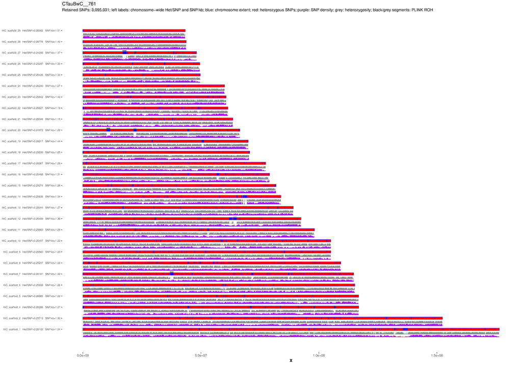

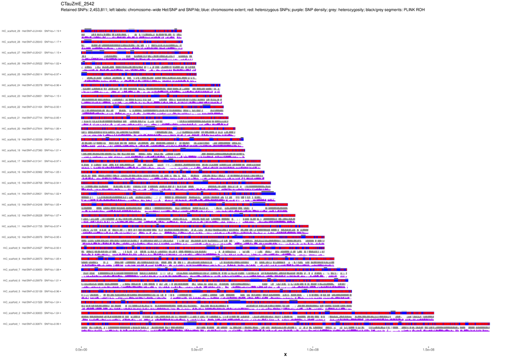

Important: You can inspect the plots better by right-clicking them and pressing "open image in new tab"

Questions:

- Which individual has more long ROH?
- Are the long ROH concentrated on a few scaffolds or spread across the genome?
- Why might heterozygosity outside long ROH be useful when comparing individuals from different demographic histories?

```
from jupyterquiz import display_quiz

display_quiz('/davidData/users/thomas/workshop/roh_quiz1_filtering.json')
```

## ROH Length Classes Across Individuals

We can summarize ROH as a fraction of the genome in different length classes. The total/sum of these is called `F_ROH`: total length in ROH divided by the genome length considered.

Computing this for many individuals from the full PLINK dataset would take longer than we want in the exercise, so here we use precomputed ROH length-class summaries:

- ROH from 1-2 Mb
- ROH from 2-5 Mb
- ROH from 5-10 Mb
- ROH longer than 10 Mb

The point here is interpretation: both the total amount of ROH and the length distribution matter.

We also include the Etosha population here, which the article reports to have experienced ancient black-wildebeest introgression in the past.

```
library(ggplot2)
library(dplyr)
library(tidyr)

het_table <- read.table("/davidData/users/thomas/workshop/het.roh.tsv", header = TRUE)

selected_maps <- c("B-Etosha", "C-Luangwa", "E.wBearded_KeSNai", "W.wBearded")
pop_labels <- c("B-Etosha" = "Etosha",
                "C-Luangwa" = "Luangwa",
                "E.wBearded_KeSNai" = "Nairobi",
                "W.wBearded" = "Serengeti")

roh_long <- het_table %>%
  filter(map %in% selected_maps) %>%
  mutate(
    map = factor(map, levels = selected_maps),
    total_froh = X1 + X2 + X3 + X4
  ) %>%
  arrange(map, total_froh) %>%
  mutate(sampleID = factor(sampleID, levels = sampleID)) %>%
  select(sampleID, map, total_froh, X1, X2, X3, X4) %>%
  pivot_longer(c(X1, X2, X3, X4), names_to = "roh_class", values_to = "froh") %>%
  mutate(roh_class = recode(roh_class,
                            X1 = "1-2 Mb",
                            X2 = "2-5 Mb",
                            X3 = "5-10 Mb",
                            X4 = ">10 Mb"),
         roh_class = factor(roh_class, levels = c("1-2 Mb", "2-5 Mb", "5-10 Mb", ">10 Mb")))

ggplot(roh_long, aes(x = sampleID, y = froh, fill = roh_class)) +
  geom_col(width = 0.85, color = "grey30", linewidth = 0.12) +
  facet_grid(. ~ map, scales = "free_x", space = "free_x",
             labeller = as_labeller(pop_labels)) +
  scale_fill_manual(values = c("1-2 Mb" = "#b8e0d6",
                               "2-5 Mb" = "#72b7a6",
                               "5-10 Mb" = "#2f887f",
                               ">10 Mb" = "#104f55")) +
  labs(x = NULL, y = expression(F[ROH]), fill = "ROH length") +
  theme_classic(base_size = 12) +
  theme(
    legend.position = "top",
    strip.background = element_rect(fill = "grey92", color = NA),
    strip.text = element_text(face = "bold"),
    axis.text.x = element_text(angle = 90, hjust = 1, vjust = 0.5, size = 6),
    panel.spacing.x = unit(0.7, "lines"),
    plot.margin = margin(8, 8, 8, 8)
  )

roh_long %>%
  group_by(map, sampleID) %>%
  summarise(total_froh = sum(froh), .groups = "drop") %>%
  group_by(map) %>%
  summarise(n = n(),
            mean_froh = mean(total_froh),
            min_froh = min(total_froh),
            max_froh = max(total_froh),
            .groups = "drop")
```

A tibble: 4 × 5

| map <fct> | n <int> | mean_froh <dbl> | min_froh <dbl> | max_froh <dbl> |
| --- | --- | --- | --- | --- |
| B-Etosha | 6 | 0.01918136 | 0.013192584 | 0.04135282 |
| C-Luangwa | 3 | 0.14730404 | 0.119062532 | 0.18821740 |
| E.wBearded_KeSNai | 10 | 0.12694961 | 0.111245447 | 0.14927988 |
| W.wBearded | 28 | 0.01219155 | 0.005130408 | 0.03584528 |

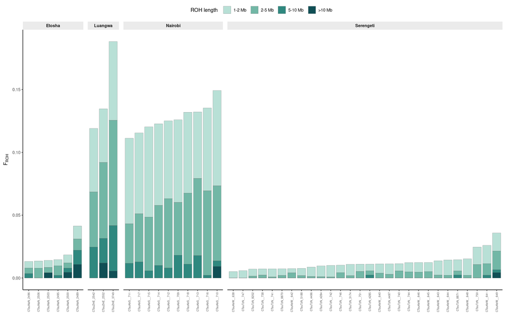

Questions:

- Which group has the highest total `F_ROH`?
- Do high-ROH individuals mostly have short ROH, long ROH, or both?
- Why can very long ROH be interpreted as evidence of more recent inbreeding than short ROH?
- Does the population with the highest heterozygosity also have the highest `F_ROH`? What does that tell us?

## Comparing heterozygosity with and without ROH

The table used earlier contains genome-wide heterozygosity (`het`) and heterozygosity after masking long ROH (`hetNoROH`). Here each individual gets one stacked bar:

- the darker base is genome-wide heterozygosity
- the lighter cap on top is the extra heterozygosity recovered after masking/removing long ROH
- the full bar height is heterozygosity outside long ROH

```
library(ggplot2)
library(dplyr)

het_table <- read.table("/davidData/users/thomas/workshop/het.roh.tsv", header = TRUE)

selected_maps <- c("B-Etosha", "C-Luangwa", "E.wBearded_KeSNai", "W.wBearded")
pop_labels <- c("B-Etosha" = "Etosha",
                "C-Luangwa" = "Luangwa",
                "E.wBearded_KeSNai" = "Nairobi",
                "W.wBearded" = "Serengeti")
pop_cols <- c("B-Etosha" = "#8a6f2a",
              "C-Luangwa" = "#1f6f78",
              "E.wBearded_KeSNai" = "#2f7d4f",
              "W.wBearded" = "#6f5aa7")

plot_table <- het_table %>%
  filter(map %in% selected_maps) %>%
  mutate(
    map = factor(map, levels = selected_maps),
    roh_remainder = pmax(hetNoROH - het, 0)
  ) %>%
  arrange(map, hetNoROH) %>%
  mutate(sampleID = factor(sampleID, levels = sampleID))

plot_long <- bind_rows(
  plot_table %>%
    transmute(sampleID, map,
              component = "Genome-wide het",
              heterozygosity = het),
  plot_table %>%
    transmute(sampleID, map,
              component = "Remainder up to het outside long ROH",
              heterozygosity = roh_remainder)
) %>%
  mutate(component = factor(component,
                            levels = c("Remainder up to het outside long ROH",
                                       "Genome-wide het")))

ggplot(plot_long, aes(x = sampleID, y = heterozygosity,
                      fill = map, alpha = component)) +
  geom_col(width = 0.85, color = "grey30", linewidth = 0.12) +
  facet_grid(. ~ map, scales = "free_x", space = "free_x",
             labeller = as_labeller(pop_labels)) +
  scale_fill_manual(values = pop_cols) +
  scale_alpha_manual(
    values = c("Genome-wide het" = 1,
               "Remainder up to het outside long ROH" = 0.35),
    breaks = c("Genome-wide het",
               "Remainder up to het outside long ROH"),
    labels = c("Genome-wide het",
               "Extra het after masking long ROH")
  ) +
  guides(fill = "none",
         alpha = guide_legend(title = NULL,
                              override.aes = list(fill = "#287f7a",
                                                  color = "grey25"))) +
  labs(x = NULL, y = "Heterozygosity") +
  theme_classic(base_size = 12) +
  theme(
    legend.position = "top",
    strip.background = element_rect(fill = "grey92", color = NA),
    strip.text = element_text(face = "bold"),
    axis.text.x = element_text(angle = 90, hjust = 1, vjust = 0.5, size = 6),
    panel.spacing.x = unit(0.7, "lines"),
    plot.margin = margin(8, 8, 8, 8)
  )

plot_table %>%
  group_by(map) %>%
  summarise(n = n(),
            mean_het = mean(het),
            mean_hetNoROH = mean(hetNoROH),
            mean_remainder = mean(roh_remainder),
            .groups = "drop")
```

A tibble: 4 × 5

| map <fct> | n <int> | mean_het <dbl> | mean_hetNoROH <dbl> | mean_remainder <dbl> |
| --- | --- | --- | --- | --- |
| B-Etosha | 6 | 0.002738167 | 0.002790833 | 5.266667e-05 |
| C-Luangwa | 3 | 0.001883333 | 0.002144333 | 2.610000e-04 |
| E.wBearded_KeSNai | 10 | 0.001918300 | 0.002189300 | 2.710000e-04 |
| W.wBearded | 28 | 0.002370286 | 0.002397321 | 2.703571e-05 |

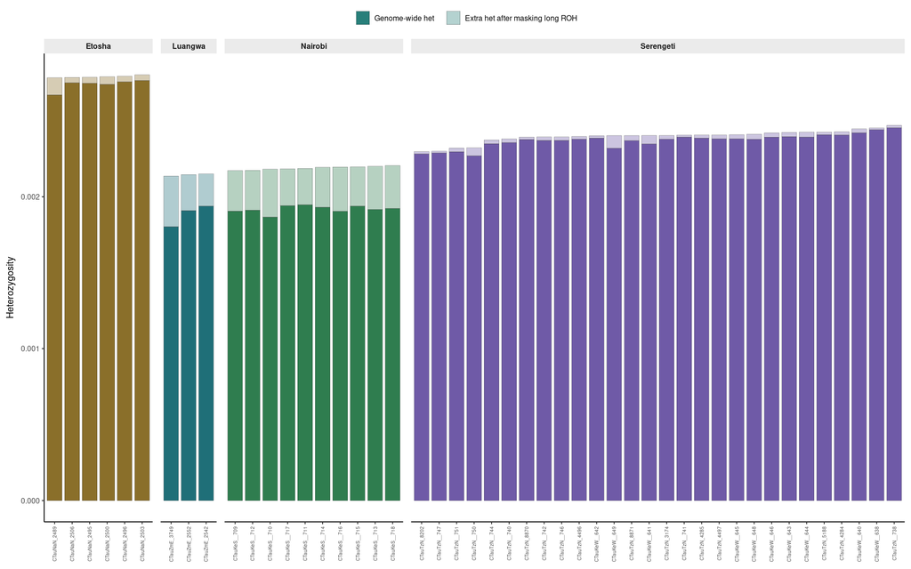

Questions:

- Which individuals show the largest gain in heterozygosity?
- What would it mean if one individual had low genome-wide heterozygosity, but fairly normal heterozygosity outside long ROH?
- Etosha has high heterozygosity. Based on previous exercises or the article, what historical process could help explain that?